# Modelos de regresión no lineales

Osmar Dominique Santana Reyes

2025-10-20

## Ejercicio 1.

Consideremos la relación de la velocidad inicial $y$ de una reacción enzimática con la concentración $x$ de sustrato. Usando el modelo de Michaelis-Menten de cinética química tenemos que

$$Y = \dfrac{\beta_0 x}{x + \beta_1} +
\epsilon$$

Los datos de velocidad inicial de reacción para una enzima tratada con puromicina se muestran a continuación:

```r
velocidad <- data.frame(
  concentracion = c(0.02, 0.06, 0.11, 0.22, 0.56, 1.10),
  velsinpur = c(47, 97, 123, 152, 191, 200),
  velconpur = c(76, 107, 139, 159, 201, 207)
)
```

| Concentración de sustrato | Velocidad inicial (sin puromicina) | Velocidad inicial (con puromicina) |
| --- | --- | --- |
| 0.02 | 47 | 76 |
| 0.06 | 97 | 107 |
| 0.11 | 123 | 139 |
| 0.22 | 152 | 159 |
| 0.56 | 191 | 201 |
| 1.10 | 200 | 207 |

Se realizará un análisis de regresión exponencial para explicar la velocidad inicial de la reacción en función de la concentración de sustrato, tanto para el caso sin puromicina como con puromicina.

```r
#Definir la función
expo <- function(x,a,b){return((a*x)/(x+b))} # a y b son los parámetros de la función
```

### Sin puromicina

Para dar los valores iniciales de los parámetros a y b, podemos fijarnos en dos observaciones:

```r
head(velocidad[c(2,5),])
```

|  | concentracion | velsinpur | velconpur |
| --- | --- | --- | --- |
| 2 | 0.06 | 97 | 107 |
| 5 | 0.56 | 191 | 201 |

Sustituyendo en el modelo, se obtiene el sistema de ecuaciones siguiente:

$$97 = \dfrac{0.06a}{0.06 + b}$$

$$191 = \dfrac{0.56a}{0.56 + b}$$

El cual se puede resolver para obtener los valores iniciales de a y b, que son 216 y 0 (redondeados), respectivamente.

```r
#La función "nls" realiza la regresión exponencial
ajuste <- nls(data = velocidad, formula = velsinpur ~ expo(concentracion, a, b), start = list(a = 216, b = 0), trace = T)
```

```
56348.00    (4.13e+00): par = (216 0)
7934.511    (2.67e+00): par = (174.0707 0.0130762)
1528.171    (2.91e+00): par = (192.0109 0.0389451)
173.2348    (1.07e+00): par = (207.741 0.06515537)
77.75053    (1.19e-01): par = (212.5541 0.0754447)
76.61358    (5.95e-03): par = (213.1319 0.07672396)
76.61075    (2.63e-04): par = (213.1682 0.07679091)
76.61074    (1.16e-05): par = (213.1699 0.07679388)
76.61074    (4.76e-07): par = (213.17 0.07679401)
```

De esta manera, el resumen del modelo es:

```r
summary(ajuste)
```

```
Formula: velsinpur ~ expo(concentracion, a, b)

Parameters:
   Estimate Std. Error t value Pr(>|t|)
a 2.132e+02  4.179e+00   51.01 8.84e-07 ***
b 7.679e-02  5.642e-03   13.61 0.000169 ***
---
Signif. codes:  0 '***' 0.001 '**' 0.01 '*' 0.05 '.' 0.1 ' ' 1

Residual standard error: 4.376 on 4 degrees of freedom

Number of iterations to convergence: 8
Achieved convergence tolerance: 4.755e-07
```

Y tiene un error residual de 76.6107425. Como los dos coeficientes son significativos para el modelo, podemos escribir el modelo ajustado como:

$$Y_{sp} = \dfrac{213.17 * X}{X + 0.0768}
+ \epsilon$$

Finalmente, la gráfica del resultado de la regresión es:

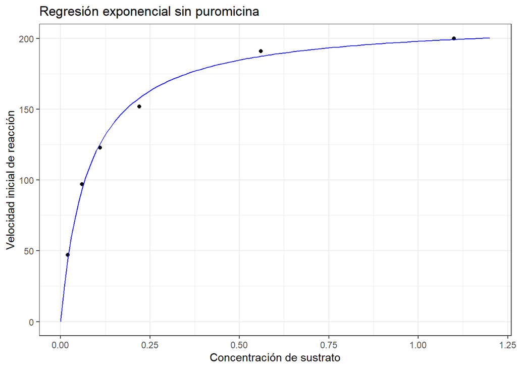

```r
#Obtenemoslos valores obtenidos para a y b
a_ajustado <- ajuste$m$getPars()["a"]
b_ajustado <- ajuste$m$getPars()["b"]

fitData <- tibble(concentracion = seq(0, 1.2, 0.01), fit = expo(concentracion, a_ajustado, b_ajustado))
nuevo <- tibble(concentracion = 0.5, fit = expo(concentracion, a_ajustado, b_ajustado))
#Graficamos el resultado de la regresión.
ggplot()+
  geom_point(velocidad, mapping = aes(x = concentracion, y = velsinpur)) +
  geom_line(fitData, mapping = aes(x = concentracion, y = fit), color="blue") +
  labs(title = "Regresión exponencial sin puromicina",
       x = "Concentración de sustrato",
       y = "Velocidad inicial de reacción") +
  theme_bw()
```

### Con puromicina

De forma análoga, podemos fijarnos en las mismas observaciones:

```r
head(velocidad[c(2,5),])
```

|  | concentracion | velsinpur | velconpur |
| --- | --- | --- | --- |
| 2 | 0.06 | 97 | 107 |
| 5 | 0.56 | 191 | 201 |

Sustituyendo en el modelo, se obtiene el sistema de ecuaciones siguiente:

$$107 = \dfrac{0.06a}{0.06 + b}$$

$$201 = \dfrac{0.56a}{0.56 + b}$$

El cual se puede resolver para obtener los valores iniciales de a y b, los cuales son 224 y 0 (redondeados), respectivamente.

```r
#La función "nls" realiza la regresión exponencial
ajuste <- nls(data = velocidad, formula = velconpur ~ expo(concentracion, a, b), start = list(a = 224, b = 0), trace = T)
```

```
47861.00    (3.68e+00): par = (224 0)
6127.812    (1.69e+00): par = (181.4608 0.01074494)
1626.139    (1.07e+00): par = (194.8704 0.02840867)
684.1106    (3.75e-01): par = (206.3847 0.04398918)
588.9035    (7.76e-02): par = (210.8436 0.05086381)
584.8662    (1.25e-02): par = (211.8958 0.05246321)
584.7611    (1.90e-03): par = (212.0822 0.05272901)
584.7587    (2.86e-04): par = (212.1113 0.05276957)
584.7586    (4.29e-05): par = (212.1157 0.05277568)
584.7586    (6.41e-06): par = (212.1163 0.05277659)
```

De esta manera, el resumen del modelo es:

```r
summary(ajuste)
```

```
Formula: velconpur ~ expo(concentracion, a, b)

Parameters:
   Estimate Std. Error t value Pr(>|t|)
a 212.11634   10.22620   20.74 3.19e-05 ***
b   0.05278    0.01068    4.94  0.00782 **
---
Signif. codes:  0 '***' 0.001 '**' 0.01 '*' 0.05 '.' 0.1 ' ' 1

Residual standard error: 12.09 on 4 degrees of freedom

Number of iterations to convergence: 9
Achieved convergence tolerance: 6.414e-06
```

Y tiene un error residual de 584.7586047. Como los dos coeficientes son significativos para el modelo, podemos escribir el modelo ajustado como:

$$Y_{cp} = \dfrac{212.12 * X}{X + 0.0528}
+ \epsilon$$

Finalmente, la gráfica del resultado de la regresión es:

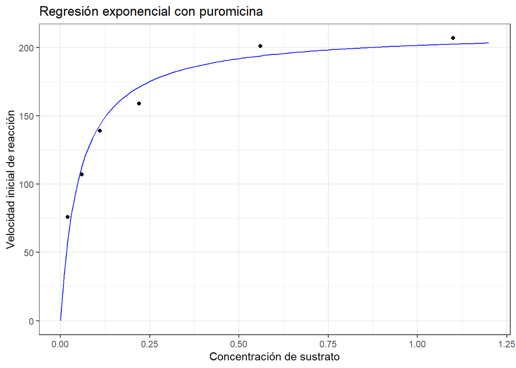

```r
#Obtenemoslos valores obtenidos para a y b
a_ajustado <- ajuste$m$getPars()["a"]
b_ajustado <- ajuste$m$getPars()["b"]

fitData <- tibble(concentracion = seq(0, 1.2, 0.01), fit = expo(concentracion, a_ajustado, b_ajustado))
nuevo <- tibble(concentracion = 0.5, fit = expo(concentracion, a_ajustado, b_ajustado))
#Graficamos el resultado de la regresión.
ggplot()+
  geom_point(velocidad, mapping = aes(x = concentracion, y = velconpur)) +
  geom_line(fitData, mapping = aes(x = concentracion, y = fit), color="blue") +
  labs(title = "Regresión exponencial con puromicina",
       x = "Concentración de sustrato",
       y = "Velocidad inicial de reacción") +
  theme_bw()
```

## Ejercicio 2.

Consideremos la relación de la presión $P$ de una masa de gas para distintos valores de volumen V. Se sabe que la relación entre estas variables sigue el siguiente modelo

$P = \beta_0 V^{-\beta_1}$ (modelo potencial $Y = \beta_0 X^{\beta_1} + \epsilon$)

Los datos son:

```r
gas <- data.frame(
  volumen = c(54.3, 61.8, 72.4, 88.7, 118.6, 194),
  presion = c(61.2, 49.5, 37.6, 28.4, 19.2, 10.1)
)
```

| Volumen | Presión |
| --- | --- |
| 54.3 | 61.2 |
| 61.8 | 49.5 |
| 72.4 | 37.6 |
| 88.7 | 28.4 |
| 118.6 | 19.2 |
| 194 | 10.1 |

Aplicando logaritmo natural a ambos lados del modelo, obtenemos:

$$\ln(P) = \ln(\beta_0) - \beta_1 \ln(V)$$

El cual es un modelo lineal con los parámetros $\ln(\beta_0)$ y $-\beta_1$.

```r
mod <- lm(log(presion) ~ log(volumen), data = gas)
summary(mod)
```

```
Call:
lm(formula = log(presion) ~ log(volumen), data = gas)

Residuals:
       1        2        3        4        5        6
 0.04469  0.01419 -0.03849 -0.03397 -0.01753  0.03110

Coefficients:
             Estimate Std. Error t value Pr(>|t|)
(Intercept)    9.6786     0.1673   57.86 5.34e-07 ***
log(volumen)  -1.4042     0.0371  -37.85 2.91e-06 ***
---
Signif. codes:  0 '***' 0.001 '**' 0.01 '*' 0.05 '.' 0.1 ' ' 1

Residual standard error: 0.03908 on 4 degrees of freedom
Multiple R-squared:  0.9972,    Adjusted R-squared:  0.9965
F-statistic:  1432 on 1 and 4 DF,  p-value: 2.911e-06
```

$$\ln(P) = 9.6785804 -1.404204 \ln(V)$$

Es decir:

$$P = 1.5971807\times 10^{4}
V^{-1.404204}$$

Finalmente, la gráfica del resultado de la regresión es:

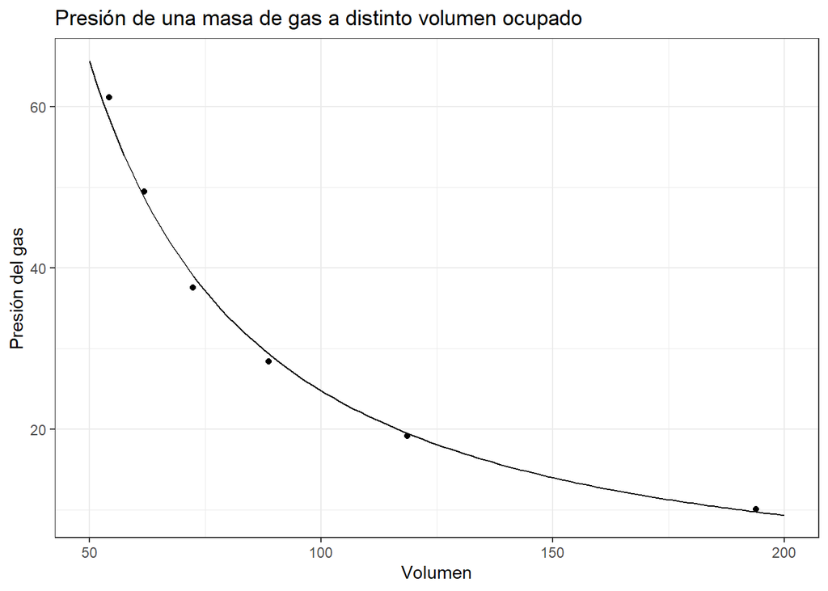

```r
ggplot(data = data.frame(x = c(50, 200)), aes(x = x)) +
  geom_point(gas, mapping = aes(x = volumen, y = presion)) +
  geom_function(fun = function(x) exp(mod$coefficients[1])*x^mod$coefficients[2]) +
  labs(title = "Presión de una masa de gas a distinto volumen ocupado",
       x = "Volumen",
       y = "Presión del gas") +
  theme_bw()
```